# Final Exam Question Bank

Stat 218

Your exam questions will be randomly selected from this bank of questions. There be a solution key posted. It is your responsibility to discuss your ideas with your group members and / or with Dr. Theobold during office hours prior to the exam.

## Golden Ticket

| Scenario | One Categorical Response | Two Categorical Variables | One Quantitative Response |
| --- | --- | --- | --- |
| Type of plot | Bar plot | Side-by-Side Bar plot, Stacked Bar plot, Mosaic plot | Dot plot, Histogram, Boxplot |
| Summary measure | Proportion | Difference in Proportions | Mean |
| Parameter notation | $\pi$ | $\pi_1 - \pi_2$ | $\mu$ |
| Statistic notation | $\widehat{p}$ | $\widehat{p}_1 - \widehat{p}_2$ | $\bar{x}$ |

## Provided Formulas

$$IQR = Q3 - Q1$$

**1.5 IQR Rule:** above $Q3 + (1.5 \times IQR)$ or below $Q1 - (1.5 \times IQR)$

$$\hat{y} = b_0 + b_1 \times
x$$

$$Residual = y - \hat{y}$$

**t-based confidence interval:** $\text{point estimate} \pm t^*_{df} \times SE$

$$SE(\mu) =
\frac{\sigma}{\sqrt{n}}$$

$$SE(\mu_1 - \mu_2) =
\sqrt{\frac{\sigma_1}{n_1} + \frac{\sigma_2}{n_2}}$$

## Final Exam Question Bank

### Wild Mushrooms

[17 points] Wild mushrooms, such as chanterelles or morels, are delicious, but eating wild mushrooms carries the risk of accidental poisoning. Even a single bite of the wrong mushroom can be enough to cause fatal poisoning. An amateur mushroom hunter is interested in finding an easy rule to differentiate poisonous and edible mushrooms. They think that the mushroom’s gills (the part which holds and releases spores) might be related to a mushroom’s edibility. They used a data set of 8124 mushrooms and their descriptions. For each mushroom, the data set includes whether it is edible or poisonous and the spacing of the gills (Broad or Narrow).

**Please Note**: According to The Audubon Society Field Guide to North American Mushrooms, there is no simple rule for determining the edibility of a mushroom; no rule like “leaflets three, leave them be” for Poisonous Oak and Ivy.

| class | Broad | Narrow | Total |
| --- | --- | --- | --- |
| Edible | 3920 | 288 | 4208 |
| Poisonous | 1692 | 2224 | 3916 |
| Total | 5612 | 2512 | 8124 |

[4 pts] Fill in each blank with one of the options in parentheses to best describe the variables collected.

Whether the mushroom is edible or poisonous is the (explanatory / response) and it is (categorical / quantitative) .

Gill size (Broad or Narrow) is the (explanatory / response) and it is (categorical / quantitative) .

[3 points] Calculate the proportion of mushrooms with a broad gill size that are poisonous. *Give appropriate notation with informative subscripts if necessary.*

**Work:**

**Answer:**

**Notation:**

[3 points] Calculate the proportion of mushrooms with a narrow gill size that are poisonous. *Give appropriate notation with informative subscripts if necessary.*

**Work:**

**Answer:**

**Notation:**

[2 points] Using your answers to (b) and (c), fill in the correct names next to each color, to label the bar chart showing the relationship between gill size (broad or narrow) and whether the mushroom is edible.

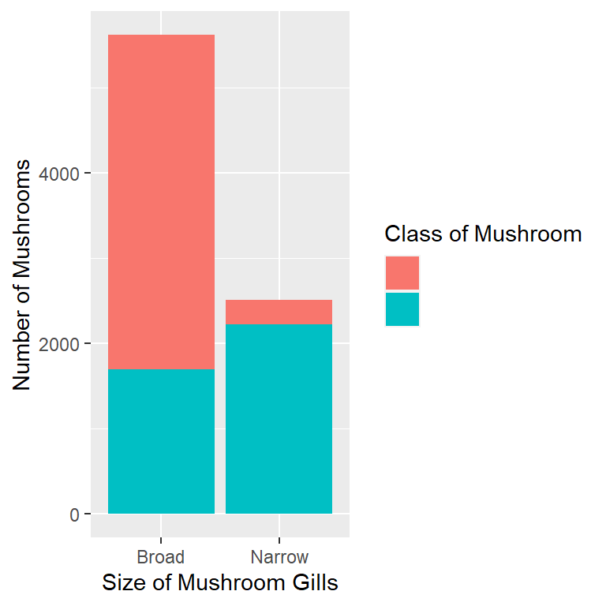

[3 points] Based on the plot, describe the relationship between a mushrooms gill size and whether it is edible or not.

### Mendelay Genetics

Mendelian inheritance refers to certain patterns of how traits are passed from parents to offspring. These general patterns were established by the Austrian monk Gregor Mendel, who performed thousands of experiments with pea plants in the 19th century. Mendel’s discoveries of how traits (such as color and shape) are passed down from one generation to the next introduced the concept of dominant and recessive modes of inheritance.

Mendelian inheritance refers to the inheritance of traits controlled by a single gene with two alleles, one of which may be completely dominant to the other. You can use a Punnett square to easily determine the expected ratios of possible genotypes in the offspring of two parents.

In the table below, we see an example of eye color inheritance. In this case, both parents are heterozygotes (Aa) for the gene. Half of the gametes produced by each parent will have the A allele, and half will have the a allele, shown on the side and the top of the Punnett square. Filling in the cells of the Punnett square gives the possible genotypes of their children. It also shows the most likely ratios of the genotypes, which in this case is 25% AA, 50% Aa, and 25% aa.

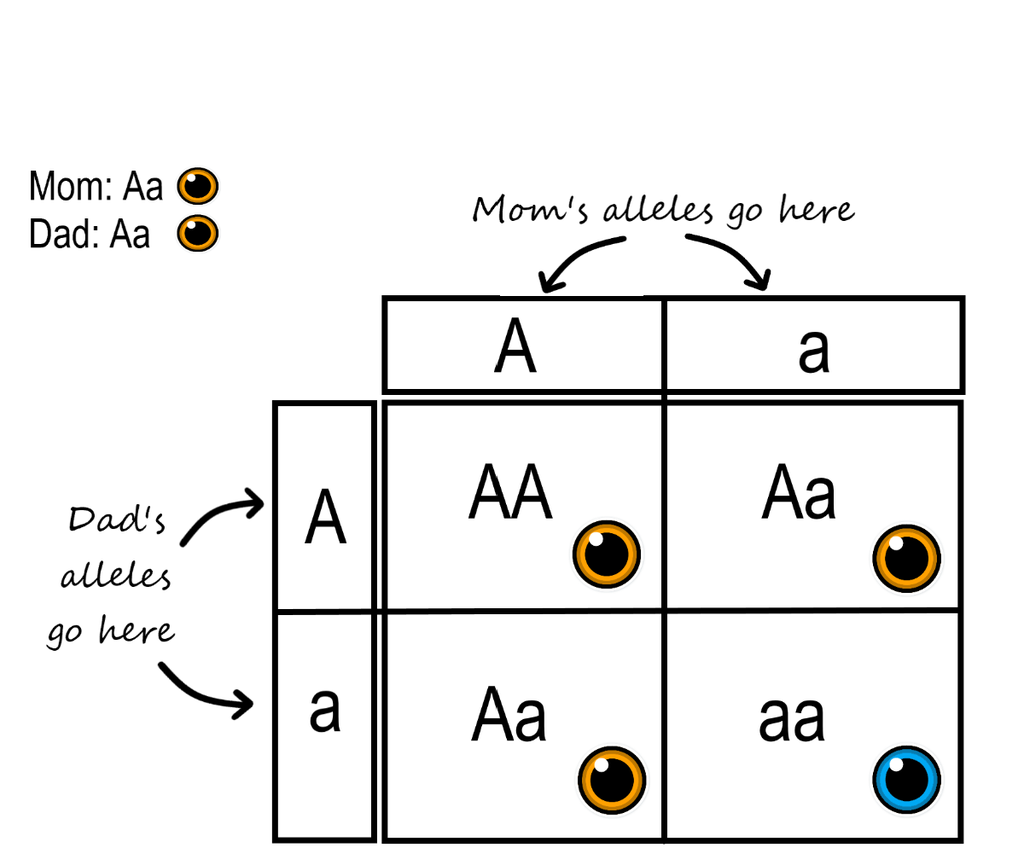

[2 points] When Mendel crossed his pea plants, he learned that tall (T) was dominant to short (t). Suppose in your Biology course you carried out an experiment to test if the plot offspring would follow Mendelian inheritance.

Fill in the table defining what the expected tallness inheritance for your plants should be.

|  | T | t |
| --- | --- | --- |
| T |  |  |
| t |  |  |

If the Mendelian inheritance is true, what proportions would you expect for each of the following genotypes? Insert the corresponding values in each cell.

[output not shown]

Actually, our table could be a bit simpler. Both the TT and Tt genotypes will present as “tall” plants, whereas tt genotypes will present as “short” plants.*

Compress your previous table into a new table with only two levels of tallness.

[output not shown]

[3 points] If the table above represents what is assumed to be true about tallness inheritance under $H_0,$ state the alternative hypothesis using either words or notation.

After you cross your plants, you measure the characteristics of the 400 offspring. You note that there are 305 tall pea plants and 95 short pea plants.

Create a table summarizing these observations.

Calculate how far “off” was your observed number of tall plants from what you expected if $H_0$ was true. Use these values to report the $X^2$ statistic for your experiment.

| Tall | Short |
| --- | --- |

**$X^2$ statistic**:

The p-value associated with your $X^2$ statistic is 0.5645424. Your Biology textbook suggests you interpret this value as:

> The large p-value proves that Mendelian inheritance is true.

What issue(s) to you have with this interpretation?

### Seasonal Colds

[22 points] A local doctor suspects that there is a seasonal trend in the occurrence of the common cold. She estimates that 40% of the cases each year occur in the winter, 40% in the spring, 10% in the summer and 10% in the fall. A random sample of 1000 patient cases was collected, and the number of cold cases for each season was recorded.

A summary table is included below:

| Season | Number of Patients |
| --- | --- |
| Fall | 165 |
| Spring | 292 |
| Summer | 169 |
| Winter | 374 |

[4 points] If the doctor’s suspicion was correct, what proportions would you expect for each cell? Insert the corresponding values in each cell.

[output not shown]

[3 points] If the table above represents what is assumed to be true under $H_0,$ state the alternative hypothesis using either words or notation.

[4 points] Compute the table of expected counts.

| Fall | Spring | Summer | Winter |
| --- | --- | --- | --- |

[2 points] What is the summer cold cell’s contribution to the $X^2$ statistic?

[2 points] Evaluate whether the conditions required to use the $\chi^2$ distribution to obtain a p-value are violated.

[3 points] An $X^2$ statistic of 124 was obtained for these data. Fill in the `R` code below to find the p-value for this statistic. *Hint:* The `lower.tail` input takes one of two options `TRUE` or `FALSE`.

```r
pchisq(_____________,
       df = ______________,
       lower.tail = ___________)
```

[4 points] Using the code you input above, a p-value less than 0.000000123 was obtained. Based on this p-value what would you conclude about the Doctor’s hypothesis regarding the distribution of colds throughout the year?

### Professor Attractiveness

[21 points] Data were scraped from *ratemyprofessors.com*, a website which allows college and university students to assign ratings to professors and campuses of American, Canadian, and United Kingdom institutions. In order for the rating to be posted, a rater must rate the professor in the following categories: `overall quality`, `level of difficulty`, and their `hotness`.

The Dean of the College of Science and Math would like to know if the difficulty rating of female professor’s at Cal Poly is related to how attractive they are perceived to be.

A table of observed counts in shown below.

| Difficulty | Attractive | Unattractive | Total |
| --- | --- | --- | --- |
| Easy | 76 | 54 | 130 |
| Hard | 45 | 170 | 215 |
| Medium | 51 | 90 | 141 |
| Total | 172 | 314 | 486 |

[3 points] What type of test should be performed with these data to address the research question?

[4 points] Write out the null and alternative hypotheses for the test you stated in **(a)**.

$H_0:$

$H_A:$

[3 points] When analyzing the data, the administrators chose to use a $\chi^2$ distribution to obtain their p-value. Was this an appropriate choice? Why or why not?

[2 points] What distribution should be used to find the p-value for the hypothesis test above?

[4 points] A p-value less than 0.000000142 ($X^2$ statistic = 50) was found using the distribution stated in **(d)**. Based on the p-value obtained, report your conclusion to the hypothesis test **in the context of the problem.**

[2 points] Compute the relative risk of being labeled “Hard” for “attractive” professors compared to “unattractive” professors.

[3 points] Interpret the relative risk you obtained in **(f)** in the context of these data. Be sure to indicate how the comparison was made!

### Guilty Decisions

[11 points] The effect of guilt on how a decision maker focuses on a problem was investigated in the *Journal of Behavioral Decision Making* (January 2007). A total of 155 volunteer students participated in the study, where each was randomly assigned to one of three emotional states (guilt, anger, or neutral) through a reading / writing task. Immediately after the task, the students were presented with a decision problem (e.g., whether or not to spend money on repairing a very old car). The researchers found that a higher proportion of students in the guilty-state group chose not to repair the car than those in the neutral-state and anger-state groups.

### Distribution of Fish on Blackfoot River

These data are not from a random sample. The goal is to catch all fish within a section of the Blackfoot River every few years to assess the health of the population. Montana Fish, Wildlife, & Parks is interested in analyzing if the prevalence of the different species of fish has stayed relative stable over the years.

| length | weight | year | section | species |
| --- | --- | --- | --- | --- |
| 540 | 1200 | 2004 | ScottyBrown | Brown Trout |
| 335 | 420 | 2002 | ScottyBrown | Brown Trout |
| 232 | 125 | 2002 | ScottyBrown | Brown Trout |
| 208 | 90 | 2000 | Johnsrud | Rainbow Trout |
| 215 | 115 | 2000 | Johnsrud | Rainbow Trout |
| 270 | 210 | 2000 | ScottyBrown | Brown Trout |
| 170 | 50 | 2006 | Johnsrud | Rainbow Trout |
| 230 | 120 | 2000 | Johnsrud | Rainbow Trout |
| 352 | 460 | 2000 | Johnsrud | Whitefish |
| 146 | 40 | 2006 | Johnsrud | Rainbow Trout |

[2 points] Based on the output above, what is the observational unit for this study?

[3 points] Based on the output above, what type of variable is `year`? Given the stated analysis, is this the correct data type for this variable?

[3 points] Based on the bar plot below, describe the relationship between the sampling year and the species of captured fish. Make direct reference to characteristics of the plot!

[figure not shown]

[5 points] The Statistician at Montana Fish, Wildlife, & Parks prefers using simulation-based methods rather than theory-based methods. They used computer simulation to obtain the null distribution below.

Fill in the steps necessary to obtain out **one** simulation on the null distribution.

Generate a new sample that could have happened if the null hypothesis was true by:

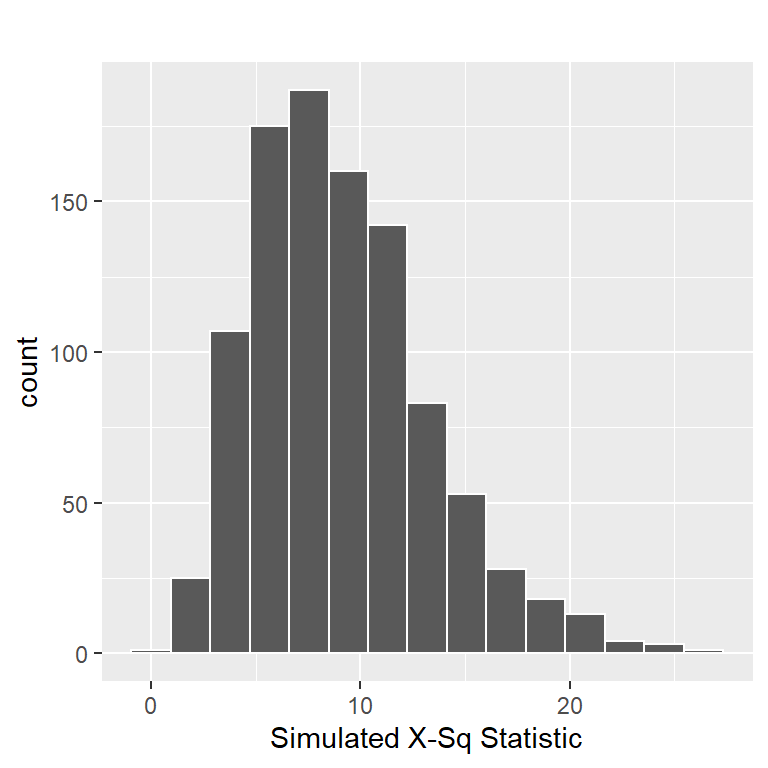

[2 points] The observed $X^2$ statistic was 57.4155167. Use this statistic to draw a line and shade the direction that should be used when calculating the p-value.

[1 point] Approximate the p-value for this hypothesis test.

[3 points] Using the conditions of the simulation-based method used, evaluate if you believe the p-value you obtained in **(f)** is accurate.

## General Concepts

[2 points] Suppose you reject the null hypothesis at the 0.05 level of significance. A colleague had planned to use a 0.01 level of significance instead. Will your colleague also reject the null hypothesis?

You are bedazzling! Congratulations on completing STAT 218!

Have a great summer!